# Determining Graduation Rate Using Regression Analysis

### 2.5 Variable Selection To choose Best Model

```r
#Use regsubsets to get exhaustive search

library(leaps)
```

```r
myfit.regsub<-regsubsets(Grad.Rate~.,data=mynewdata,nvmax=16)
myfit.summary<-summary(myfit.regsub)


par(mfrow=c(2,2))
#plot rss
plot(myfit.summary$rss,xlab = "Variable number", ylab = "RSS")

#plot adjusted R square and maximum point
plot(myfit.summary$adjr2,xlab = "Variable number", ylab = "Adjust R-Squared")
which.max(myfit.summary$adjr2)
```

```
## [1] 11
```

```r
#plotcp
plot(myfit.summary$cp, xlab = "Variable number", ylab = "Cp")
which.min(myfit.summary$cp)
```

```
## [1] 11
```

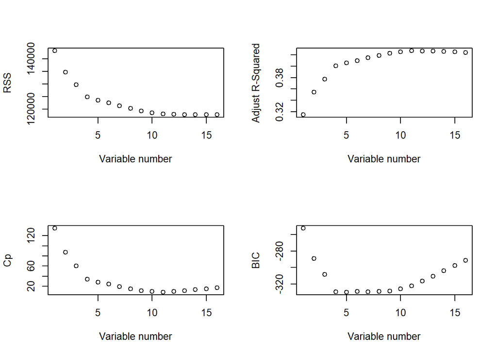

```r
#plotbic
plot(myfit.summary$bic, xlab = "Variable number", ylab = "BIC")
```

```r
which.min(myfit.summary$bic)
```

```
## [1] 5
```

BIC uses 5 variables while other models use 11 variables for their exhaustive search, and since we choose the model that uses the least number of variables, we choose the BIC model as the best model. This is so that we can avoid overfitting, abd also contruct and an easy to interpret model.

```r
coef(myfit.regsub,5)
```

```
##   (Intercept)          Apps   P.Undergrad      Outstate    Room.Board
## 36.0804711172  0.0009484343 -0.0020398448  0.0012328433  0.0016725455
##   perc.alumni
##  0.3598385186
```

We can now use only 5 variables to fit the data.

```r
myfit.lm<-lm(Grad.Rate~Apps+P.Undergrad+Outstate+Room.Board+perc.alumni, data = mynewdata)
summary(myfit.lm)
```

```
##
## Call:
## lm(formula = Grad.Rate ~ Apps + P.Undergrad + Outstate + Room.Board +
##     perc.alumni, data = mynewdata)
##
## Residuals:
##     Min      1Q  Median      3Q     Max
## -48.992  -7.549  -0.443   7.669  54.170
##
## Coefficients:
##               Estimate Std. Error t value Pr(>|t|)
## (Intercept) 36.0804711  2.1652675  16.663  < 2e-16 ***
## Apps         0.0009484  0.0001450   6.539 1.20e-10 ***
## P.Undergrad -0.0020398  0.0003773  -5.406 8.86e-08 ***
## Outstate     0.0012328  0.0001971   6.255 6.94e-10 ***
## Room.Board   0.0016725  0.0006230   2.685  0.00744 **
## perc.alumni  0.3598385  0.0496758   7.244 1.16e-12 ***
## ---
## Signif. codes:  0 '***' 0.001 '**' 0.01 '*' 0.05 '.' 0.1 ' ' 1
##
## Residual standard error: 13.34 on 694 degrees of freedom
## Multiple R-squared:  0.4099, Adjusted R-squared:  0.4056
## F-statistic: 96.41 on 5 and 694 DF,  p-value: < 2.2e-16
```

- **Coefficients and Significance Significance**
  - Intercept is when all other predictors are zero.It shows to be significant but this is not practical as for there to be a Graduation Rate, other predictors cannot be zero.
  - All other predictors are significant, and this supports our variable selection.
- **Adjusted R-squared**
  - 40.56 percent of the variability of Graduation Rate can be explained by our current model which has selected 5 predictors which are statistically significant better and thus give us the current best model. The above adjusted R-Squared is however lower than the adusted R-squared for Model 2.
- **p-value of F-statistic**
  - The F-statistic also has a low p value *<2.2e-16*, which shows that one of the predictors is significant in predicting the Grad.Rate.In this case, we reject the Null hypothesis.

#### **Diagnostic Plots for Model with 5 best Predictors**

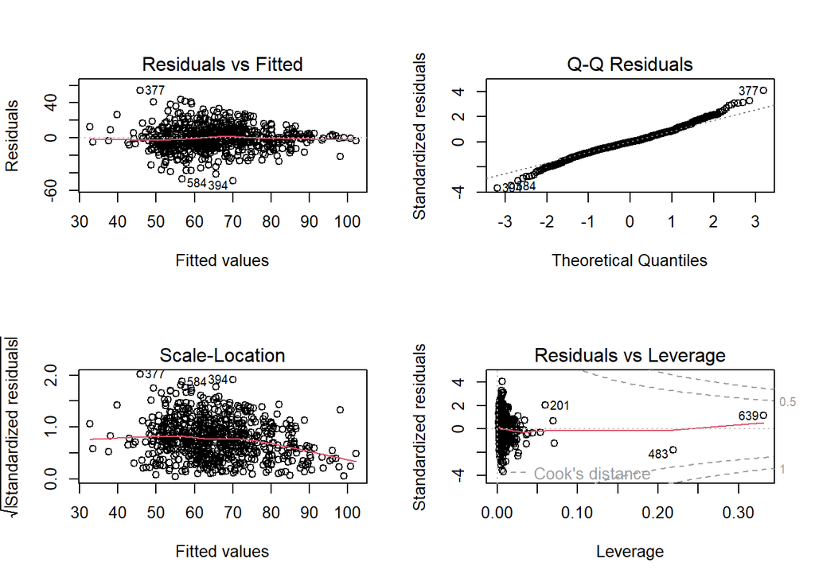

```r
par(mfrow=c(2,2))
plot(myfit.lm)
```

- The residual vs Fitted plot has not changed that much when compared to the model 2 plot but there is some slight improvement in how the red line is approximately at zero throughout.We can assume linear relationship between predictors and and the outcome.
- The Q-Q plot still shows that the points deviate from the straight line in the tails of the distribution suggesting that normal distribution of residuals is not fully satisfied but it is relatively better as majority of points are on the line..
- The Scale-Location plot shows a relatively constant spread of points around the zero which indicates a constant variance.
- The Residuals vs Leverage plot suggests that there are still some high influential points in the data. Point 639 and 483 can be easily spotted